# Poisson fSuSiE

William R.P. Denault

2025-08-28

**Note:** This vignette describes a development version of Poisson-fSuSiE.

## Inhomogeneous Poisson Process

We developed **Poisson-fSuSiE** to fine-map read counts over gene bodies or other sequence-based assays. We assume the data arise from an overdispersed inhomogeneous Poisson process, where genetic variants (SNPs) affect the intensity in specific regions.

Below, we simulate such a dataset. In this example, two causal SNPs influence specific regions of the intensity function.

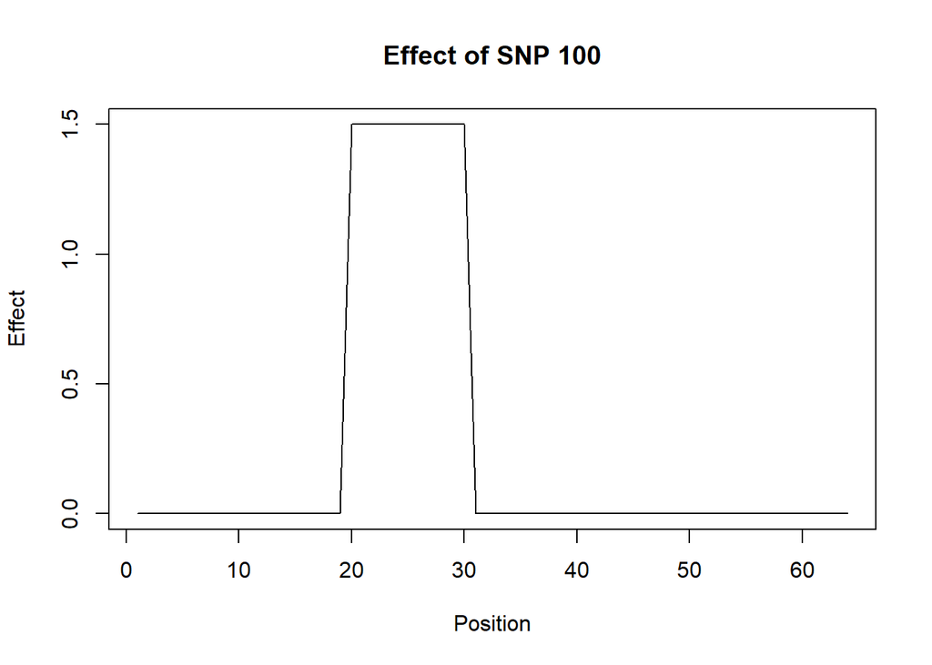

```r
library(fsusieR)
library(susieR)
library(ebnm)

set.seed(1)
"%!in%" <- function(x, y) !(x %in% y)

data(N3finemapping)
X_raw <- N3finemapping$X
N <- 200
mysd <- 1.1
genotype <- X_raw[sample(1:nrow(X_raw), size = N), 1:100]
idx_zero_var <- which(apply(genotype, 2, var) < 1e-15)
if (length(idx_zero_var) > 0) genotype <- genotype[, -idx_zero_var]
X <- (genotype - 0.99 * min(genotype)) / (0.5 * max(genotype))
G <- X

lev_res <- 6
L <- 2
lf <- list()
lf[[1]] <- rep(0, 2^lev_res); lf[[1]][20:30] <- 1.5
lf[[2]] <- rep(0, 2^lev_res); lf[[2]][50:60] <- 1.5

true_pos <- sample(1:ncol(G), replace = FALSE, size = L)

plot(lf[[1]], type = "l", main = paste("Effect of SNP", true_pos[1]), ylab = "Effect", xlab = "Position")
```

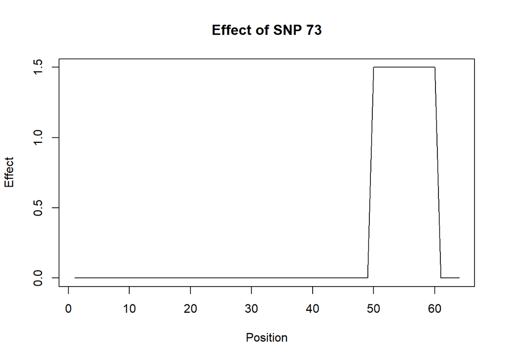

```r
plot(lf[[2]], type = "l", main = paste("Effect of SNP", true_pos[2]), ylab = "Effect", xlab = "Position")
```

```r
count.data <- vector("list", N)
True_intensity <- list()
for (i in 1:N) {
  predictor <- rep(0, 2^lev_res)
  for (l in 1:L) {
    G[, true_pos[l]] <- G[, true_pos[l]] - min(G[, true_pos[l]])
    predictor <- predictor + G[i, true_pos[l]] * lf[[l]] + 0.3
  }
  lambda <- exp(predictor + rnorm(length(predictor), sd = mysd))
  count.data[[i]] <- rpois(n = length(predictor), lambda = lambda)
  True_intensity[[i]] <- log(lambda)
}
Y <- do.call(rbind, count.data)
True_intensity <- do.call(rbind, True_intensity)
```

## Comparison of Fine-Mapping Methods

We compare three methods for fine-mapping this data:

1. Log1p transformation of counts with fSuSiE
2. Haar-Fisz transformed data with fSuSiE
3. Poisson-fSuSiE using an overdispersed Poisson model

```r
res0 <- susiF(Y = log1p(Y), X = X, L = 3)
```

```
## [1] "Scaling columns of X and Y to have unit variance"
## [1] "Starting initialization"
## [1] "Data transform"
## [1] "Discarding  0 wavelet coefficients out of  64"
## [1] "Data transform done"
## [1] "Initializing prior"
## [1] "Initialization done"
## [1] "Fitting effect  1 , iter 1"
## [1] "Fitting effect  2 , iter 1"
## [1] "Fitting effect  3 , iter 1"
## [1] "Discarding  1  effects"
## [1] "Fitting effect  1 , iter 2"
## [1] "Fitting effect  2 , iter 2"
## [1] "Discarding  1  effects"
## [1] "Greedy search and backfitting done"
## [1] "Fitting effect  1 , iter 3"
## [1] "Fitting effect  2 , iter 3"
## [1] "Fine mapping done, refining effect estimates using cylce spinning wavelet transform"
```

```r
res1 <- susiF(Y = HFT(Y), X = X, L = 3)
```

```
## [1] "Scaling columns of X and Y to have unit variance"
## [1] "Starting initialization"
## [1] "Data transform"
## [1] "Discarding  0 wavelet coefficients out of  64"
## [1] "Data transform done"
## [1] "Initializing prior"
## [1] "Initialization done"
## [1] "Fitting effect  1 , iter 1"
## [1] "Fitting effect  2 , iter 1"
## [1] "Fitting effect  3 , iter 1"
## [1] "Discarding  1  effects"
## [1] "Fitting effect  1 , iter 2"
## [1] "Fitting effect  2 , iter 2"
## [1] "Discarding  1  effects"
## [1] "Greedy search and backfitting done"
## [1] "Fitting effect  1 , iter 3"
## [1] "Fitting effect  2 , iter 3"
## [1] "Fine mapping done, refining effect estimates using cylce spinning wavelet transform"
```

```r
res <- Pois_fSuSiE(Y = Y, X = X, L = 3 , post_processing = "smash")
```

```
## [1] "No Z matrix provided,  the algorithm will perform fine-mapping only"
## [1] "Posterior log intensity computed for iter  1"
## [1] "Done initializing susiF.obj"
```

```
## [1] "Scaling columns of X and Y to have unit variance"
## [1] "Starting initialization"
## [1] "Data transform"
## [1] "Discarding  0 wavelet coefficients out of  64"
## [1] "Data transform done"
## [1] "Initializing prior"
## [1] "Initialization done"
## [1] "Fitting effect  1 , iter 1"
## [1] "Fitting effect  2 , iter 1"
## [1] "Fitting effect  3 , iter 1"
## [1] "Discarding  1  effects"
## [1] "Fitting effect  1 , iter 2"
## [1] "Fitting effect  2 , iter 2"
## [1] "Discarding  1  effects"
## [1] "Greedy search and backfitting done"
## [1] "Fitting effect  1 , iter 3"
## [1] "Fitting effect  2 , iter 3"
## [[1]]
## [1] 100
##
## [[2]]
## [1] 73
##
## [1] "Posterior log intensity computed for iter  2"
```

```
## [1] "Scaling columns of X and Y to have unit variance"
## [1] "Starting initialization"
## [1] "Data transform"
## [1] "Discarding  0 wavelet coefficients out of  64"
## [1] "Data transform done"
## [1] "Initializing prior"
## [1] "Initialization done"
## [1] "Fitting effect  1 , iter 1"
## [1] "Fitting effect  2 , iter 1"
## [1] "Fitting effect  3 , iter 1"
## [1] "Discarding  1  effects"
## [1] "Fitting effect  1 , iter 2"
## [1] "Fitting effect  2 , iter 2"
## [1] "Discarding  1  effects"
## [1] "Greedy search and backfitting done"
```

[output cut: 32 more lines]

### Credible Sets

```r
true_pos
```

```
## [1] 100  73
```

```r
res0$cs
```

```
## [[1]]
## [1] 100
##
## [[2]]
## [1] 73
```

```r
res1$cs
```

```
## [[1]]
## [1] 100
##
## [[2]]
## [1] 73
```

```r
res$susiF.obj$cs
```

```
## [[1]]
## [1] 100
##
## [[2]]
## [1] 73
```

### Estimated Intensity Functions

We can compare the estimated intensity function (note the log1p nor the Haar-Fisz transform do really estimate the Poisson process intensity)

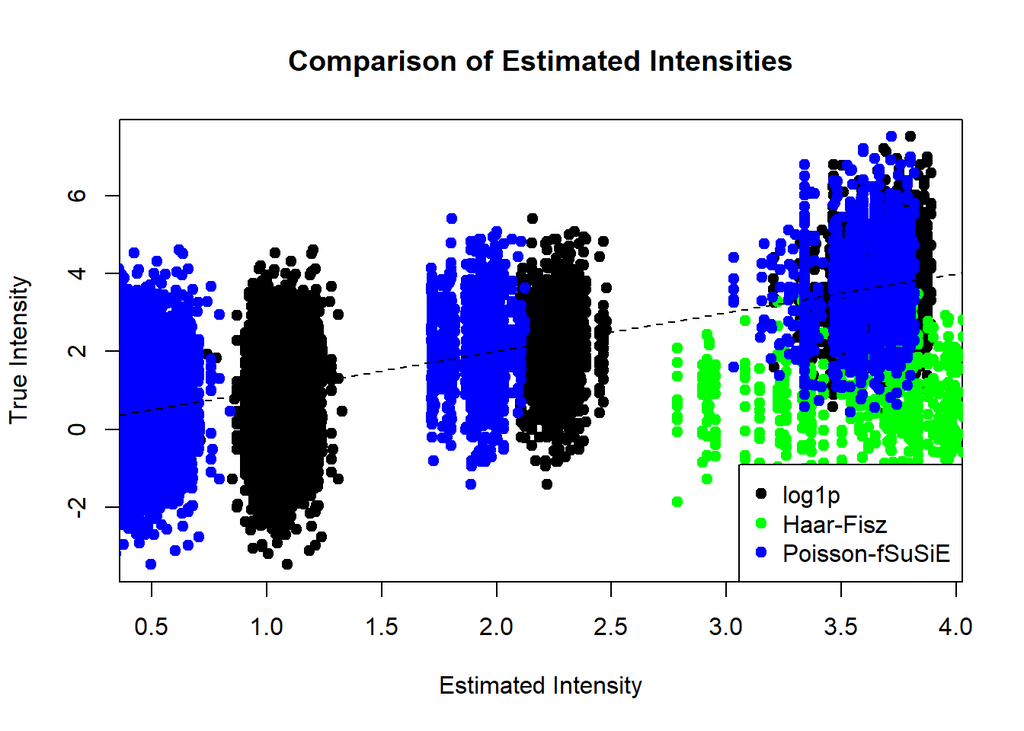

```r
plot(res0$ind_fitted_func, True_intensity, pch = 19, xlab = "Estimated Intensity", ylab = "True Intensity", main = "Comparison of Estimated Intensities")
points(res1$ind_fitted_func, True_intensity, col = "green", pch = 19)
points(res$susiF.obj$ind_fitted_func, True_intensity, col = "blue", pch = 19)
abline(a = 0, b = 1, lty = 2)
legend("bottomright", legend = c("log1p", "Haar-Fisz", "Poisson-fSuSiE"), col = c("black", "green", "blue"), pch = 19)
```

### Mean Squared Error (MSE)

```r
mean((c(res1$ind_fitted_func) - c(True_intensity))^2)
```

```
## [1] 242.8882
```

```r
mean((c(res0$ind_fitted_func) - c(True_intensity))^2)
```

```
## [1] 1.378066
```

```r
mean((c(res$susiF.obj$ind_fitted_func) - c(True_intensity))^2)
```

```
## [1] 1.228012
```

### Recovered Effect Functions

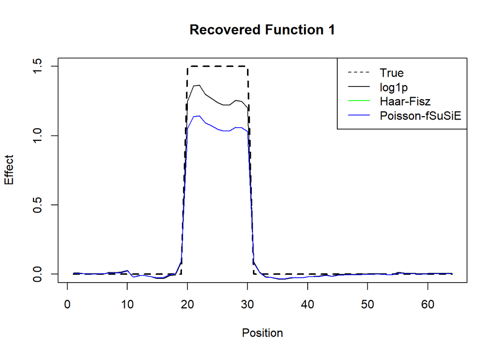

```r
plot(lf[[1]], lwd = 2, lty = 2, type = "l", main = "Recovered Function 1", ylab = "Effect", xlab = "Position")
lines(res0$fitted_func[[1]], col = "black")
lines(res1$fitted_func[[1]], col = "green")
lines(res$susiF.obj$fitted_func[[1]], col = "blue")
legend("topright", legend = c("True", "log1p", "Haar-Fisz", "Poisson-fSuSiE"), col = c("black", "black", "green", "blue"), lty = c(2, 1, 1, 1))
```

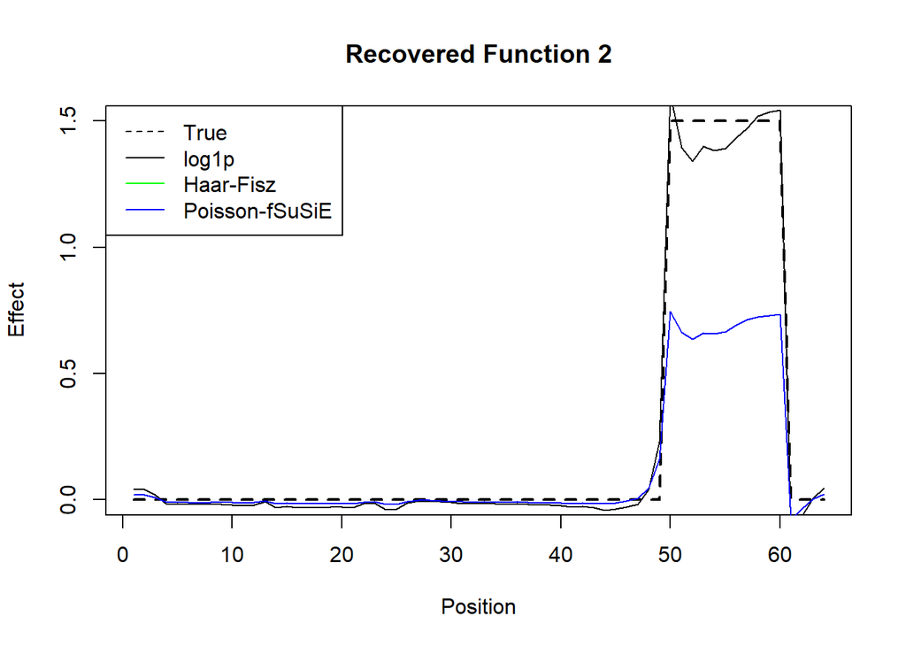

```r
plot(lf[[2]], lwd = 2, lty = 2, type = "l", main = "Recovered Function 2", ylab = "Effect", xlab = "Position")
lines(res0$fitted_func[[2]], col = "black")
lines(res1$fitted_func[[2]], col = "green")
lines(res$susiF.obj$fitted_func[[2]], col = "blue")
legend("topleft", legend = c("True", "log1p", "Haar-Fisz", "Poisson-fSuSiE"), col = c("black", "black", "green", "blue"), lty = c(2, 1, 1, 1))
```

## Speed–Accuracy Trade-Off

Poisson-fSuSiE performs iterative updates that require repeatedly fitting fSuSiE models. This can be computationally expensive.

```r
res_2iter <- Pois_fSuSiE(Y = Y, X = X, L = 3, max.iter = 2, post_processing = "smash")
```

```
## [1] "No Z matrix provided,  the algorithm will perform fine-mapping only"
## [1] "Posterior log intensity computed for iter  1"
## [1] "Done initializing susiF.obj"
```

```
## [1] "Scaling columns of X and Y to have unit variance"
## [1] "Starting initialization"
## [1] "Data transform"
## [1] "Discarding  0 wavelet coefficients out of  64"
## [1] "Data transform done"
## [1] "Initializing prior"
## [1] "Initialization done"
## [1] "Fitting effect  1 , iter 1"
## [1] "Fitting effect  2 , iter 1"
## [1] "Fitting effect  3 , iter 1"
## [1] "Discarding  1  effects"
## [1] "Fitting effect  1 , iter 2"
## [1] "Fitting effect  2 , iter 2"
## [1] "Discarding  1  effects"
## [1] "Greedy search and backfitting done"
```

[output cut: 32 more lines]

```r
res_2iter$susiF.obj$cs
```

```
## [[1]]
## [1] 100
##
## [[2]]
## [1] 73
```

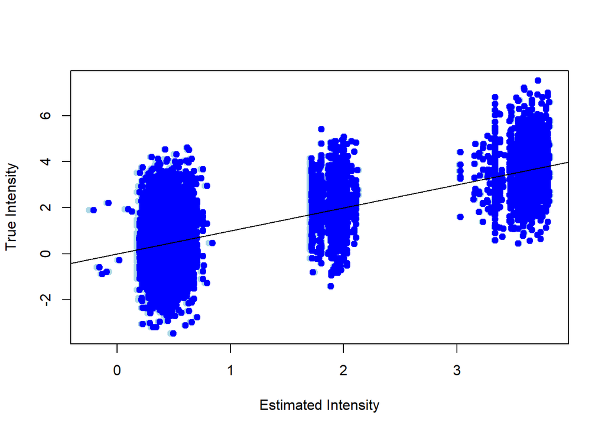

```r
plot(res_2iter$susiF.obj$ind_fitted_func, True_intensity, col = "lightblue", pch = 19, xlab = "Estimated Intensity", ylab = "True Intensity")
points(res$susiF.obj$ind_fitted_func, True_intensity, col = "blue", pch = 19)
abline(a = 0, b = 1)
```

You can see that for the lowest intensity the estimated intensity differ

```r
mean ( (res_2iter$susiF.obj$fitted_func[[2]] -  lf[[2]])^2)
```

```
## [1] 0.1125693
```

```r
mean ( (res $susiF.obj$fitted_func[[2]] -  lf[[2]])^2)
```

```
## [1] 0.112956
```

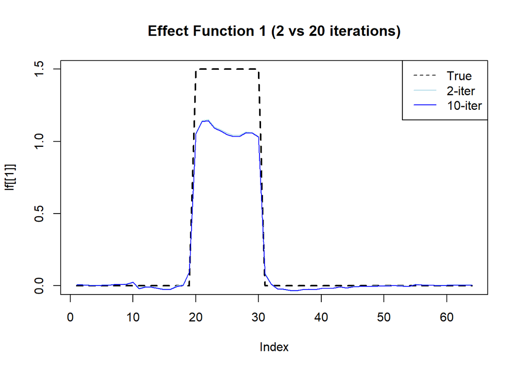

```r
plot(lf[[1]], lwd = 2, lty = 2, type = "l", main = "Effect Function 1 (2 vs 20 iterations)")
lines(res_2iter$susiF.obj$fitted_func[[1]], col = "lightblue")
lines(res$susiF.obj$fitted_func[[1]], col = "blue")
legend("topright", legend = c("True", "2-iter", "10-iter"), col = c("black", "lightblue", "blue"), lty = c(2, 1, 1))
```

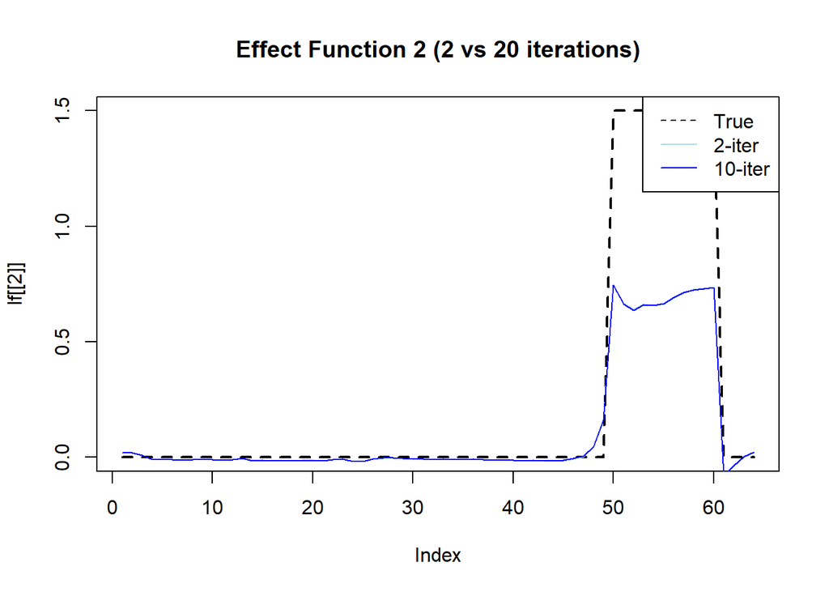

```r
plot(lf[[2]], lwd = 2, lty = 2, type = "l", main = "Effect Function 2 (2 vs 20 iterations)")
lines(res_2iter$susiF.obj$fitted_func[[2]], col = "lightblue")
lines(res$susiF.obj$fitted_func[[2]], col = "blue")
legend("topright", legend = c("True", "2-iter", "10-iter"), col = c("black", "lightblue", "blue"), lty = c(2, 1, 1))
```

## Evolution of the Posterior intensity

```r
res <- Pois_fSuSiE(Y = Y, X = X, L = 3 ,max.iter=20, post_processing = "HMM", print=TRUE )
```

```
## [1] "No Z matrix provided,  the algorithm will perform fine-mapping only"
## [1] "Posterior log intensity computed for iter  1"
## [1] "Done initializing susiF.obj"
```

```
## [1] "Scaling columns of X and Y to have unit variance"
## [1] "Starting initialization"
## [1] "Data transform"
## [1] "Discarding  0 wavelet coefficients out of  64"
## [1] "Data transform done"
## [1] "Initializing prior"
## [1] "Initialization done"
## [1] "Fitting effect  1 , iter 1"
## [1] "Fitting effect  2 , iter 1"
## [1] "Fitting effect  3 , iter 1"
## [1] "Discarding  1  effects"
## [1] "Fitting effect  1 , iter 2"
## [1] "Fitting effect  2 , iter 2"
## [1] "Discarding  1  effects"
## [1] "Greedy search and backfitting done"
## [1] "Fitting effect  1 , iter 3"
## [1] "Fitting effect  2 , iter 3"
## [[1]]
## [1] 100
##
## [[2]]
## [1] 73
```

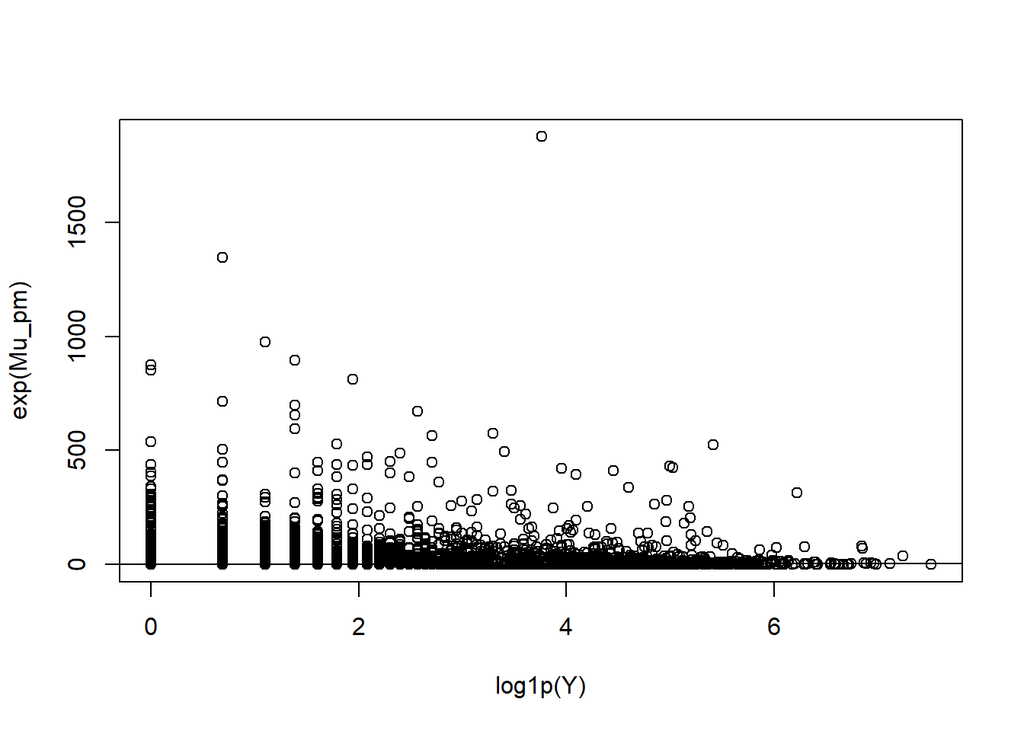

```
## [1] "Posterior log intensity computed for iter  2"
```

```
## [1] "Scaling columns of X and Y to have unit variance"
## [1] "Starting initialization"
## [1] "Data transform"
## [1] "Discarding  0 wavelet coefficients out of  64"
## [1] "Data transform done"
## [1] "Initializing prior"
## [1] "Initialization done"
## [1] "Fitting effect  1 , iter 1"
## [1] "Fitting effect  2 , iter 1"
## [1] "Fitting effect  3 , iter 1"
## [1] "Discarding  1  effects"
## [1] "Fitting effect  1 , iter 2"
## [1] "Fitting effect  2 , iter 2"
## [1] "Discarding  1  effects"
## [1] "Greedy search and backfitting done"
## [1] "Fitting effect  1 , iter 3"
## [1] "Fitting effect  2 , iter 3"
## [[1]]
## [1] 100
##
## [[2]]
## [1] 73
```

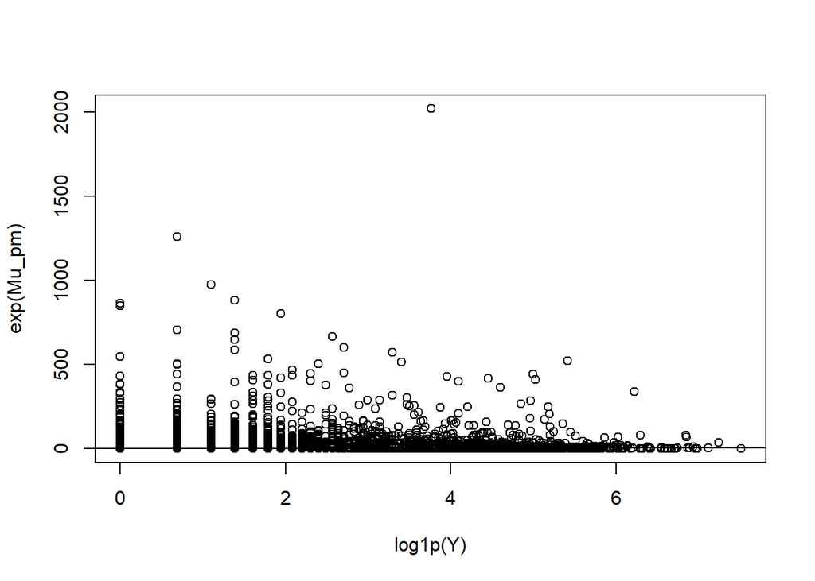

```
## [1] "Posterior log intensity computed for iter  3"
```

```
## [1] "Scaling columns of X and Y to have unit variance"
## [1] "Starting initialization"
## [1] "Data transform"
## [1] "Discarding  0 wavelet coefficients out of  64"
## [1] "Data transform done"
## [1] "Initializing prior"
## [1] "Initialization done"
## [1] "Fitting effect  1 , iter 1"
## [1] "Fitting effect  2 , iter 1"
## [1] "Fitting effect  3 , iter 1"
## [1] "Discarding  1  effects"
## [1] "Fitting effect  1 , iter 2"
## [1] "Fitting effect  2 , iter 2"
## [1] "Discarding  1  effects"
## [1] "Greedy search and backfitting done"
## [1] "Fitting effect  1 , iter 3"
## [1] "Fitting effect  2 , iter 3"
## [[1]]
## [1] 100
##
## [[2]]
## [1] 73
```

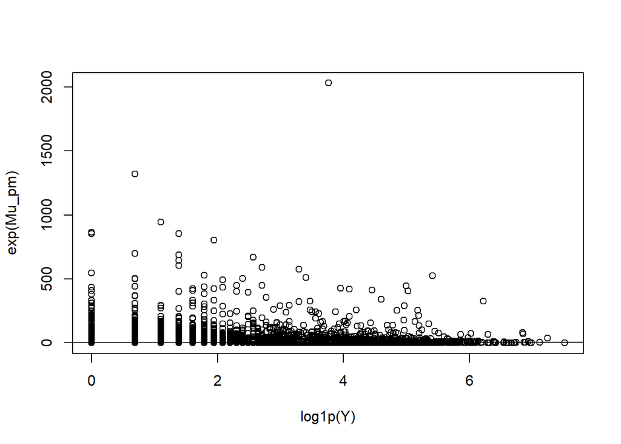

```
## [1] "Posterior log intensity computed for iter  4"
```

```
## [1] "Scaling columns of X and Y to have unit variance"
## [1] "Starting initialization"
## [1] "Data transform"
## [1] "Discarding  0 wavelet coefficients out of  64"
## [1] "Data transform done"
## [1] "Initializing prior"
## [1] "Initialization done"
## [1] "Fitting effect  1 , iter 1"
## [1] "Fitting effect  2 , iter 1"
## [1] "Fitting effect  3 , iter 1"
## [1] "Discarding  1  effects"
## [1] "Fitting effect  1 , iter 2"
## [1] "Fitting effect  2 , iter 2"
## [1] "Discarding  1  effects"
## [1] "Greedy search and backfitting done"
## [1] "Fitting effect  1 , iter 3"
## [1] "Fitting effect  2 , iter 3"
## [[1]]
## [1] 100
##
## [[2]]
## [1] 73
```

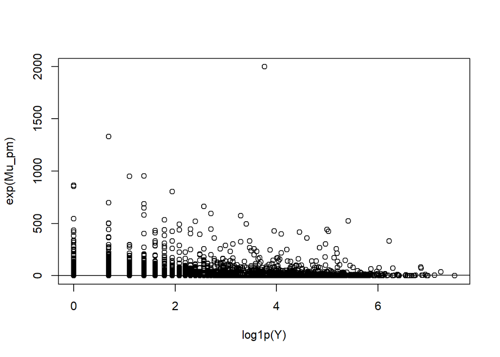

```
## [1] "Posterior log intensity computed for iter  5"
```

```
## [1] "Scaling columns of X and Y to have unit variance"
## [1] "Starting initialization"
## [1] "Data transform"
## [1] "Discarding  0 wavelet coefficients out of  64"
## [1] "Data transform done"
## [1] "Initializing prior"
## [1] "Initialization done"
## [1] "Fitting effect  1 , iter 1"
## [1] "Fitting effect  2 , iter 1"
## [1] "Fitting effect  3 , iter 1"
## [1] "Discarding  1  effects"
## [1] "Fitting effect  1 , iter 2"
## [1] "Fitting effect  2 , iter 2"
## [1] "Discarding  1  effects"
## [1] "Greedy search and backfitting done"
## [1] "Fitting effect  1 , iter 3"
## [1] "Fitting effect  2 , iter 3"
## [[1]]
## [1] 100
##
## [[2]]
## [1] 73
```

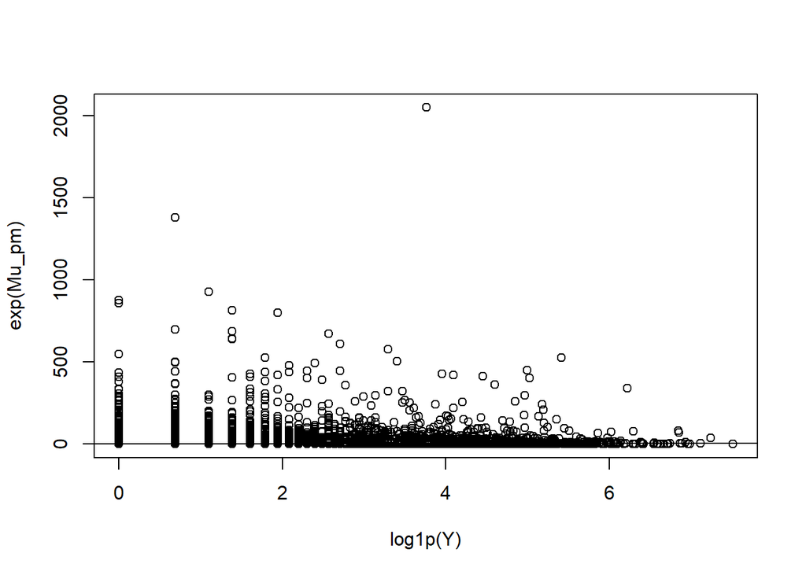

```
## [1] "Posterior log intensity computed for iter  6"
```

```
## [1] "Scaling columns of X and Y to have unit variance"
## [1] "Starting initialization"
## [1] "Data transform"
## [1] "Discarding  0 wavelet coefficients out of  64"
## [1] "Data transform done"
## [1] "Initializing prior"
## [1] "Initialization done"
## [1] "Fitting effect  1 , iter 1"
## [1] "Fitting effect  2 , iter 1"
## [1] "Fitting effect  3 , iter 1"
## [1] "Discarding  1  effects"
## [1] "Fitting effect  1 , iter 2"
## [1] "Fitting effect  2 , iter 2"
## [1] "Discarding  1  effects"
## [1] "Greedy search and backfitting done"
## [1] "Fitting effect  1 , iter 3"
## [1] "Fitting effect  2 , iter 3"
## [[1]]
## [1] 100
##
## [[2]]
## [1] 73
```

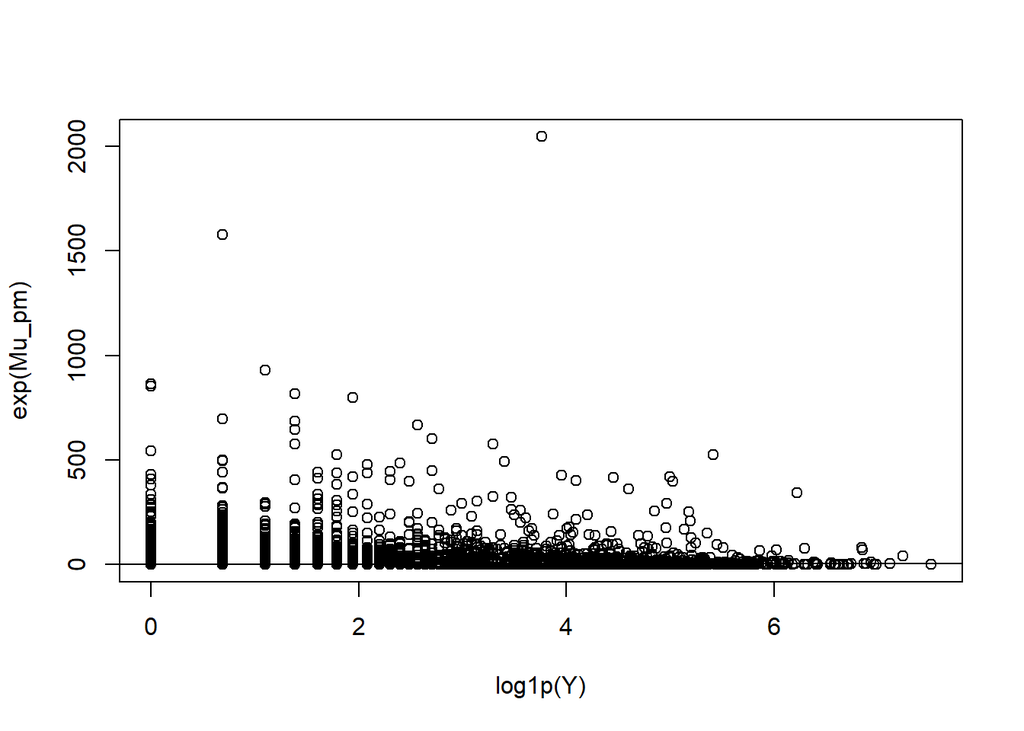

```
## [1] "Posterior log intensity computed for iter  7"
```

```
## [1] "Scaling columns of X and Y to have unit variance"
## [1] "Starting initialization"
## [1] "Data transform"
## [1] "Discarding  0 wavelet coefficients out of  64"
## [1] "Data transform done"
## [1] "Initializing prior"
## [1] "Initialization done"
## [1] "Fitting effect  1 , iter 1"
## [1] "Fitting effect  2 , iter 1"
## [1] "Fitting effect  3 , iter 1"
## [1] "Discarding  1  effects"
## [1] "Fitting effect  1 , iter 2"
## [1] "Fitting effect  2 , iter 2"
## [1] "Discarding  1  effects"
## [1] "Greedy search and backfitting done"
## [1] "Fitting effect  1 , iter 3"
## [1] "Fitting effect  2 , iter 3"
## [[1]]
## [1] 100
##
## [[2]]
## [1] 73
```

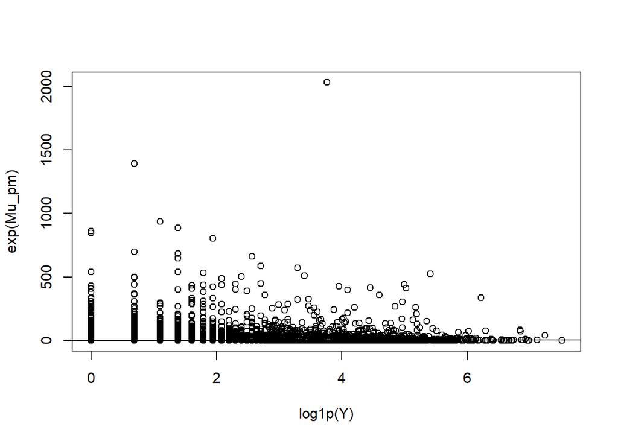

```
## [1] "Posterior log intensity computed for iter  8"
```

```
## [1] "Scaling columns of X and Y to have unit variance"
## [1] "Starting initialization"
## [1] "Data transform"
## [1] "Discarding  0 wavelet coefficients out of  64"
## [1] "Data transform done"
## [1] "Initializing prior"
## [1] "Initialization done"
## [1] "Fitting effect  1 , iter 1"
## [1] "Fitting effect  2 , iter 1"
## [1] "Fitting effect  3 , iter 1"
## [1] "Discarding  1  effects"
## [1] "Fitting effect  1 , iter 2"
## [1] "Fitting effect  2 , iter 2"
## [1] "Discarding  1  effects"
## [1] "Greedy search and backfitting done"
## [1] "Fitting effect  1 , iter 3"
## [1] "Fitting effect  2 , iter 3"
## [[1]]
## [1] 100
##
## [[2]]
## [1] 73
```

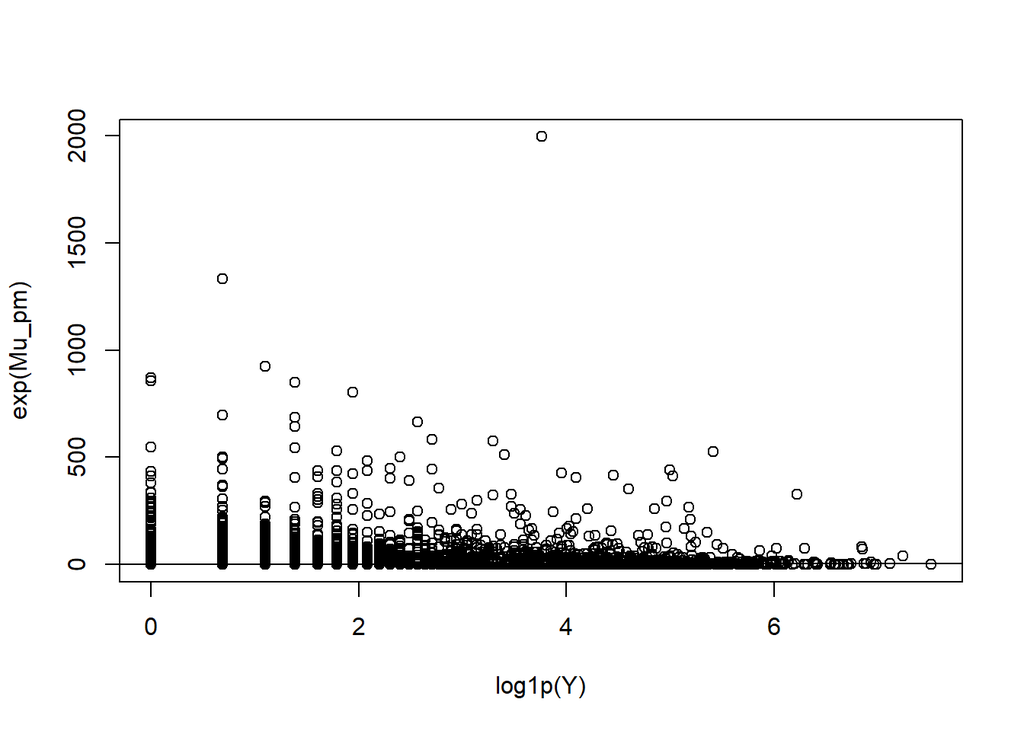

```
## [1] "Posterior log intensity computed for iter  9"
```

```
## [1] "Scaling columns of X and Y to have unit variance"
## [1] "Starting initialization"
## [1] "Data transform"
## [1] "Discarding  0 wavelet coefficients out of  64"
## [1] "Data transform done"
## [1] "Initializing prior"
## [1] "Initialization done"
## [1] "Fitting effect  1 , iter 1"
## [1] "Fitting effect  2 , iter 1"
## [1] "Fitting effect  3 , iter 1"
## [1] "Discarding  1  effects"
## [1] "Fitting effect  1 , iter 2"
## [1] "Fitting effect  2 , iter 2"
## [1] "Discarding  1  effects"
## [1] "Greedy search and backfitting done"
## [1] "Fitting effect  1 , iter 3"
## [1] "Fitting effect  2 , iter 3"
## [[1]]
## [1] 100
##
## [[2]]
## [1] 73
```

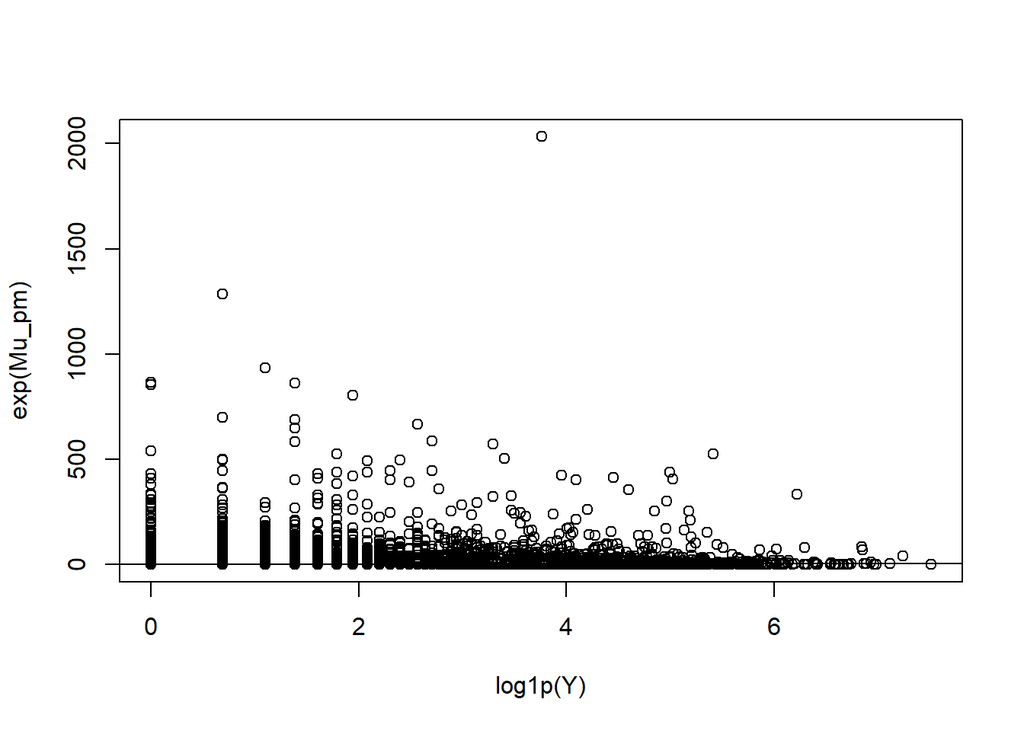

```
## [1] "Posterior log intensity computed for iter  10"
```

```
## [1] "Scaling columns of X and Y to have unit variance"
## [1] "Starting initialization"
## [1] "Data transform"
## [1] "Discarding  0 wavelet coefficients out of  64"
## [1] "Data transform done"
## [1] "Initializing prior"
## [1] "Initialization done"
## [1] "Fitting effect  1 , iter 1"
## [1] "Fitting effect  2 , iter 1"
## [1] "Fitting effect  3 , iter 1"
## [1] "Discarding  1  effects"
## [1] "Fitting effect  1 , iter 2"
## [1] "Fitting effect  2 , iter 2"
## [1] "Discarding  1  effects"
## [1] "Greedy search and backfitting done"
## [1] "Fitting effect  1 , iter 3"
## [1] "Fitting effect  2 , iter 3"
## [[1]]
## [1] 100
##
## [[2]]
## [1] 73
```

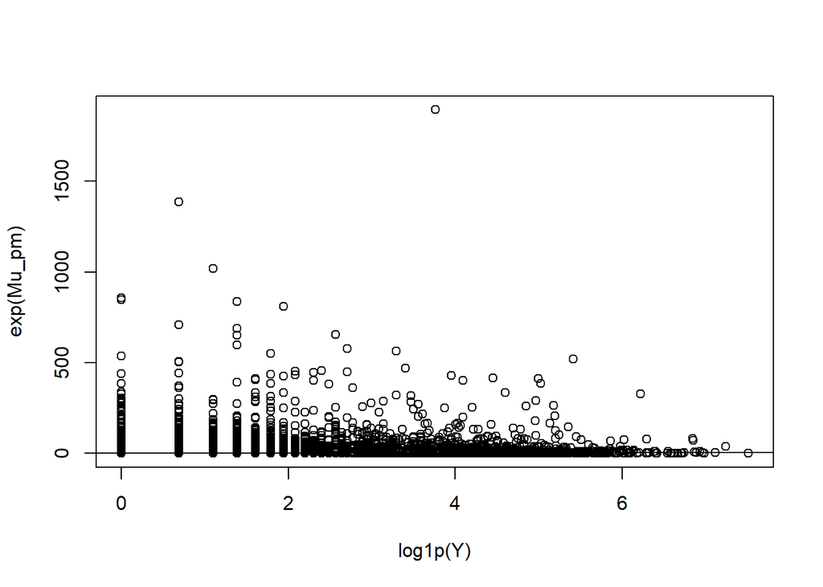

```
## [1] "Posterior log intensity computed for iter  11"
```

```
## [1] "Scaling columns of X and Y to have unit variance"
## [1] "Starting initialization"
## [1] "Data transform"
## [1] "Discarding  0 wavelet coefficients out of  64"
## [1] "Data transform done"
## [1] "Initializing prior"
## [1] "Initialization done"
## [1] "Fitting effect  1 , iter 1"
## [1] "Fitting effect  2 , iter 1"
## [1] "Fitting effect  3 , iter 1"
## [1] "Discarding  1  effects"
## [1] "Fitting effect  1 , iter 2"
## [1] "Fitting effect  2 , iter 2"
## [1] "Discarding  1  effects"
## [1] "Greedy search and backfitting done"
## [1] "Fitting effect  1 , iter 3"
## [1] "Fitting effect  2 , iter 3"
## [[1]]
## [1] 100
##
## [[2]]
## [1] 73
```

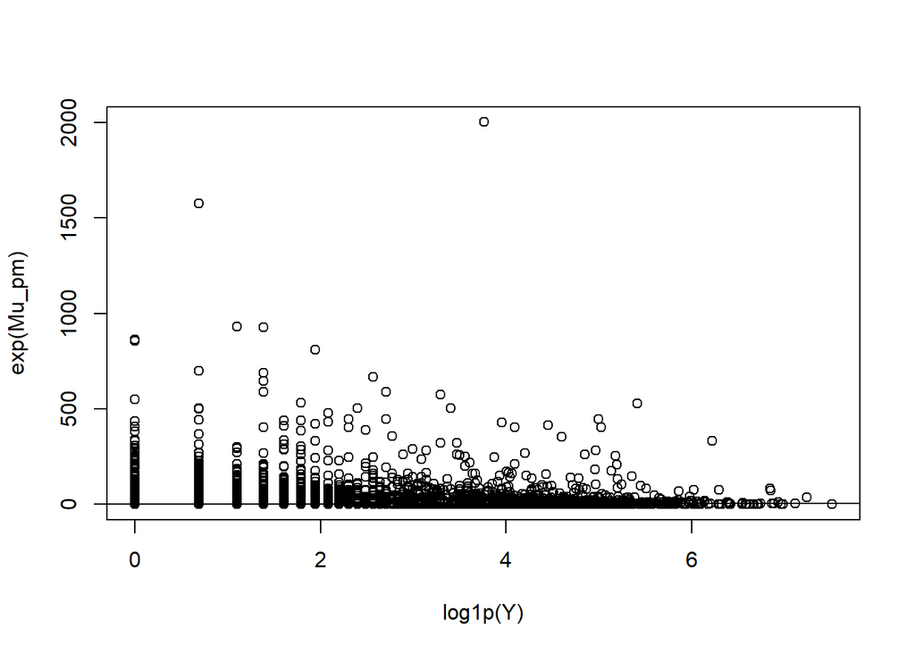

```
## [1] "Posterior log intensity computed for iter  12"
```

```
## [1] "Scaling columns of X and Y to have unit variance"
## [1] "Starting initialization"
## [1] "Data transform"
## [1] "Discarding  0 wavelet coefficients out of  64"
## [1] "Data transform done"
## [1] "Initializing prior"
## [1] "Initialization done"
## [1] "Fitting effect  1 , iter 1"
## [1] "Fitting effect  2 , iter 1"
## [1] "Fitting effect  3 , iter 1"
## [1] "Discarding  1  effects"
## [1] "Fitting effect  1 , iter 2"
## [1] "Fitting effect  2 , iter 2"
## [1] "Discarding  1  effects"
## [1] "Greedy search and backfitting done"
## [1] "Fitting effect  1 , iter 3"
## [1] "Fitting effect  2 , iter 3"
## [[1]]
## [1] 100
##
## [[2]]
## [1] 73
```

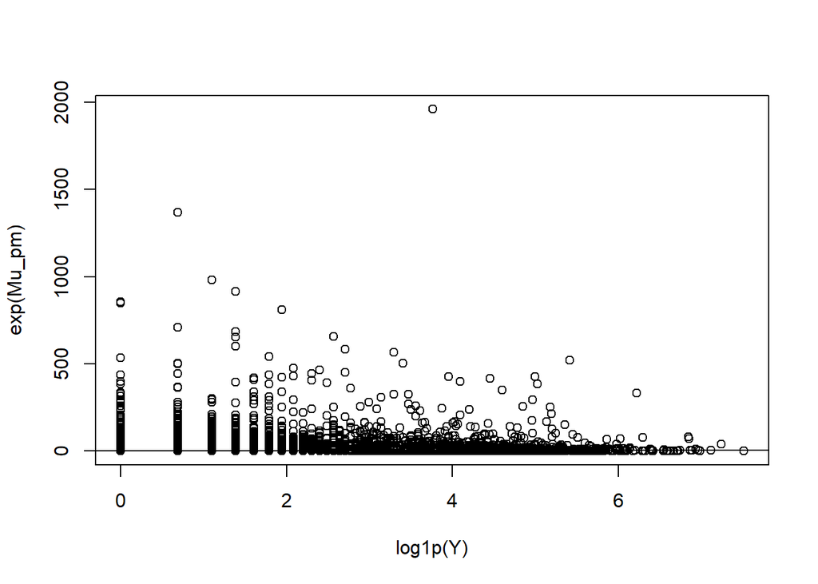

```
## [1] "Posterior log intensity computed for iter  13"
```

```
## [1] "Scaling columns of X and Y to have unit variance"
## [1] "Starting initialization"
## [1] "Data transform"
## [1] "Discarding  0 wavelet coefficients out of  64"
## [1] "Data transform done"
## [1] "Initializing prior"
## [1] "Initialization done"
## [1] "Fitting effect  1 , iter 1"
## [1] "Fitting effect  2 , iter 1"
## [1] "Fitting effect  3 , iter 1"
## [1] "Discarding  1  effects"
## [1] "Fitting effect  1 , iter 2"
## [1] "Fitting effect  2 , iter 2"
## [1] "Discarding  1  effects"
## [1] "Greedy search and backfitting done"
## [1] "Fitting effect  1 , iter 3"
## [1] "Fitting effect  2 , iter 3"
## [[1]]
## [1] 100
##
## [[2]]
## [1] 73
```

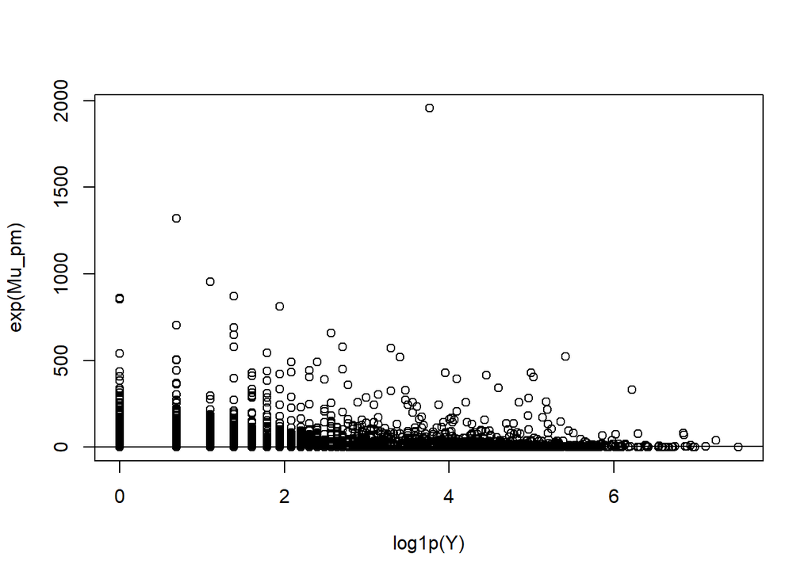

```
## [1] "Posterior log intensity computed for iter  14"
```

```
## [1] "Scaling columns of X and Y to have unit variance"
## [1] "Starting initialization"
## [1] "Data transform"
## [1] "Discarding  0 wavelet coefficients out of  64"
## [1] "Data transform done"
## [1] "Initializing prior"
## [1] "Initialization done"
## [1] "Fitting effect  1 , iter 1"
## [1] "Fitting effect  2 , iter 1"
## [1] "Fitting effect  3 , iter 1"
## [1] "Discarding  1  effects"
## [1] "Fitting effect  1 , iter 2"
## [1] "Fitting effect  2 , iter 2"
## [1] "Discarding  1  effects"
## [1] "Greedy search and backfitting done"
## [1] "Fitting effect  1 , iter 3"
## [1] "Fitting effect  2 , iter 3"
## [[1]]
## [1] 100
##
## [[2]]
## [1] 73
```

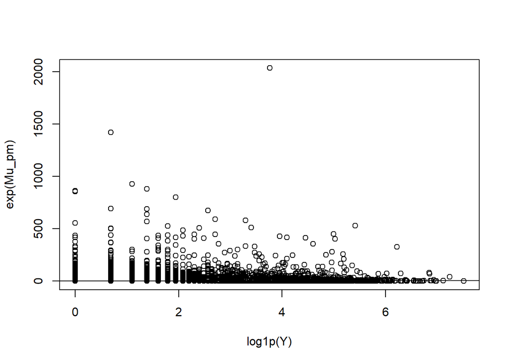

```
## [1] "Posterior log intensity computed for iter  15"
```

```
## [1] "Scaling columns of X and Y to have unit variance"
## [1] "Starting initialization"
## [1] "Data transform"
## [1] "Discarding  0 wavelet coefficients out of  64"
## [1] "Data transform done"
## [1] "Initializing prior"
## [1] "Initialization done"
## [1] "Fitting effect  1 , iter 1"
## [1] "Fitting effect  2 , iter 1"
## [1] "Fitting effect  3 , iter 1"
## [1] "Discarding  1  effects"
## [1] "Fitting effect  1 , iter 2"
## [1] "Fitting effect  2 , iter 2"
## [1] "Discarding  1  effects"
## [1] "Greedy search and backfitting done"
## [1] "Fitting effect  1 , iter 3"
## [1] "Fitting effect  2 , iter 3"
## [[1]]
## [1] 100
##
## [[2]]
## [1] 73
```

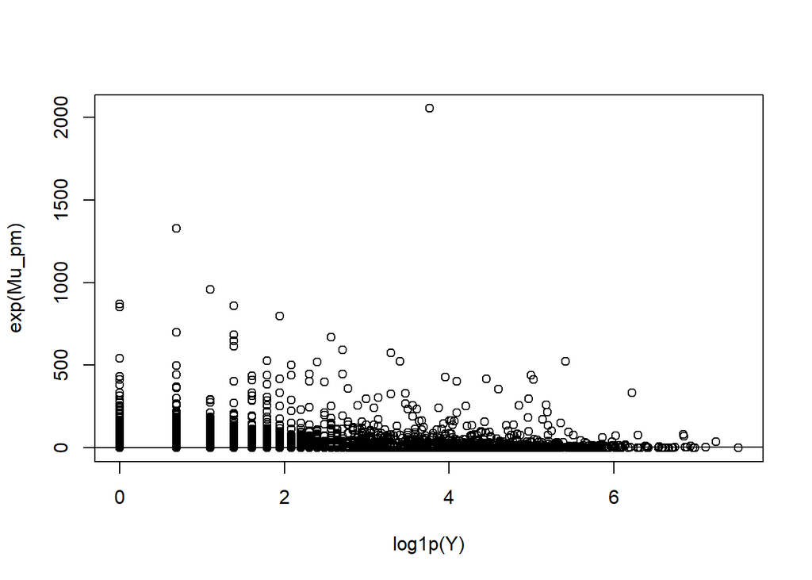

```
## [1] "Posterior log intensity computed for iter  16"
```

```
## [1] "Scaling columns of X and Y to have unit variance"
## [1] "Starting initialization"
## [1] "Data transform"
## [1] "Discarding  0 wavelet coefficients out of  64"
## [1] "Data transform done"
## [1] "Initializing prior"
## [1] "Initialization done"
## [1] "Fitting effect  1 , iter 1"
## [1] "Fitting effect  2 , iter 1"
## [1] "Fitting effect  3 , iter 1"
## [1] "Discarding  1  effects"
## [1] "Fitting effect  1 , iter 2"
## [1] "Fitting effect  2 , iter 2"
## [1] "Discarding  1  effects"
## [1] "Greedy search and backfitting done"
## [1] "Fitting effect  1 , iter 3"
## [1] "Fitting effect  2 , iter 3"
## [[1]]
## [1] 100
##
## [[2]]
## [1] 73
```

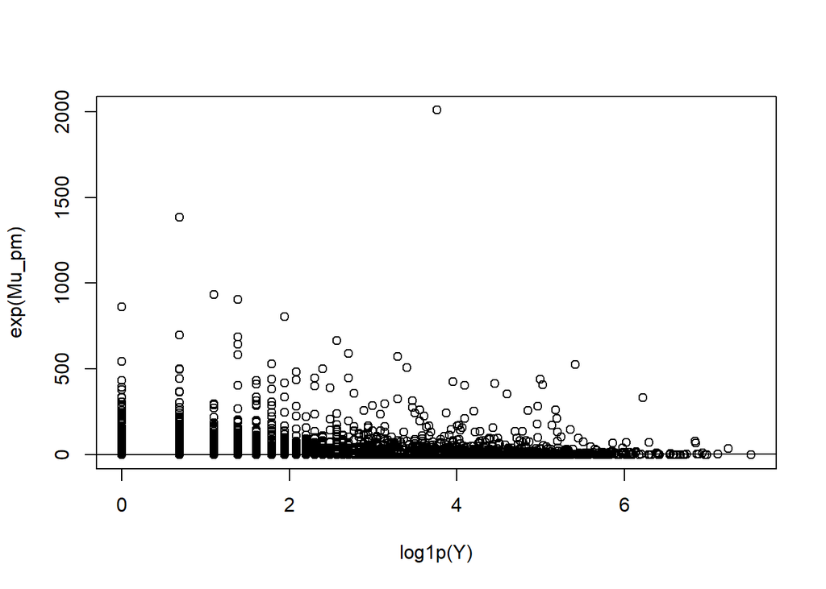

```
## [1] "Posterior log intensity computed for iter  17"
```

```
## [1] "Scaling columns of X and Y to have unit variance"
## [1] "Starting initialization"
## [1] "Data transform"
## [1] "Discarding  0 wavelet coefficients out of  64"
## [1] "Data transform done"
## [1] "Initializing prior"
## [1] "Initialization done"
## [1] "Fitting effect  1 , iter 1"
## [1] "Fitting effect  2 , iter 1"
## [1] "Fitting effect  3 , iter 1"
## [1] "Discarding  1  effects"
## [1] "Fitting effect  1 , iter 2"
## [1] "Fitting effect  2 , iter 2"
## [1] "Discarding  1  effects"
## [1] "Greedy search and backfitting done"
## [1] "Fitting effect  1 , iter 3"
## [1] "Fitting effect  2 , iter 3"
## [[1]]
## [1] 100
##
## [[2]]
## [1] 73
```

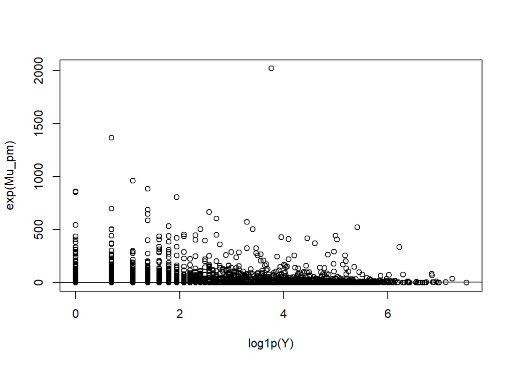

```
## [1] "Posterior log intensity computed for iter  18"
```

```
## [1] "Scaling columns of X and Y to have unit variance"
## [1] "Starting initialization"
## [1] "Data transform"
## [1] "Discarding  0 wavelet coefficients out of  64"
## [1] "Data transform done"
## [1] "Initializing prior"
## [1] "Initialization done"
## [1] "Fitting effect  1 , iter 1"
## [1] "Fitting effect  2 , iter 1"
## [1] "Fitting effect  3 , iter 1"
## [1] "Discarding  1  effects"
## [1] "Fitting effect  1 , iter 2"
## [1] "Fitting effect  2 , iter 2"
## [1] "Discarding  1  effects"
## [1] "Greedy search and backfitting done"
## [1] "Fitting effect  1 , iter 3"
## [1] "Fitting effect  2 , iter 3"
## [[1]]
## [1] 100
##
## [[2]]
## [1] 73
```

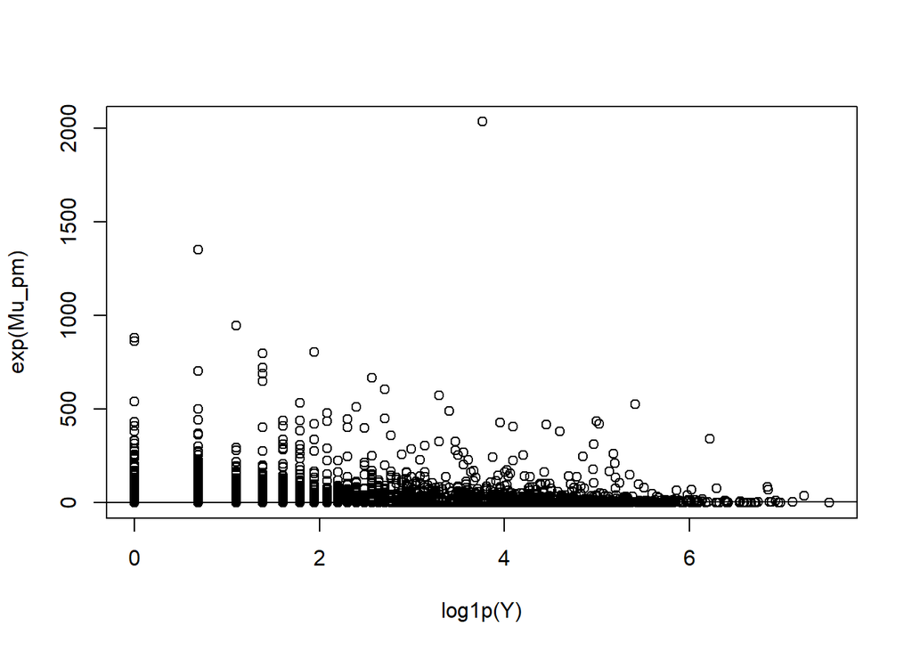

```
## [1] "Posterior log intensity computed for iter  19"
```

```
## [1] "Scaling columns of X and Y to have unit variance"
## [1] "Starting initialization"
## [1] "Data transform"
## [1] "Discarding  0 wavelet coefficients out of  64"
## [1] "Data transform done"
## [1] "Initializing prior"
## [1] "Initialization done"
## [1] "Fitting effect  1 , iter 1"
## [1] "Fitting effect  2 , iter 1"
## [1] "Fitting effect  3 , iter 1"
## [1] "Discarding  1  effects"
## [1] "Fitting effect  1 , iter 2"
## [1] "Fitting effect  2 , iter 2"
## [1] "Discarding  1  effects"
## [1] "Greedy search and backfitting done"
## [1] "Fitting effect  1 , iter 3"
## [1] "Fitting effect  2 , iter 3"
## [[1]]
## [1] 100
##
## [[2]]
## [1] 73
```

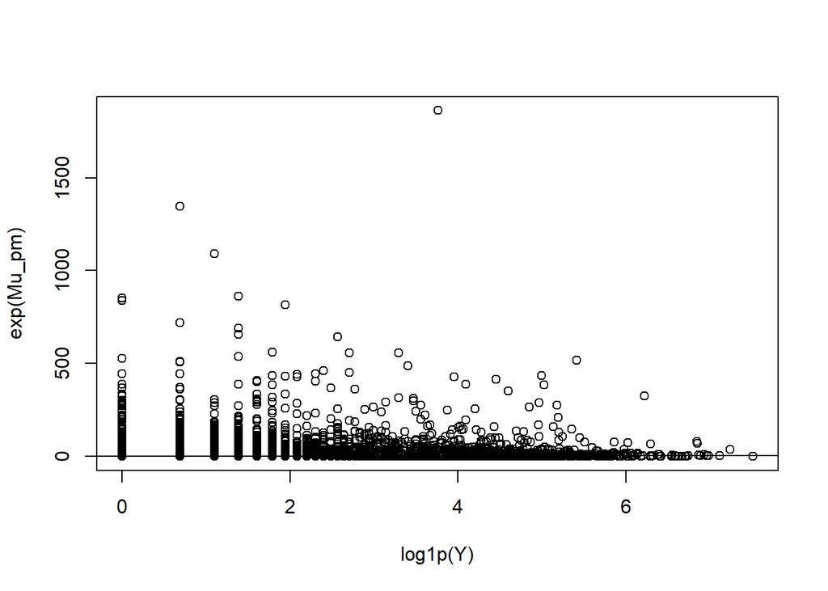

```
## [1] "Posterior log intensity computed for iter  20"
## [1] "Scaling columns of X and Y to have unit variance"
## [1] "Starting initialization"
## [1] "Data transform"
## [1] "Discarding  0 wavelet coefficients out of  64"
## [1] "Data transform done"
## [1] "Initializing prior"
## [1] "Initialization done"
## [1] "Fitting effect  1 , iter 1"
## [1] "Fitting effect  2 , iter 1"
## [1] "Fitting effect  3 , iter 1"
## [1] "Discarding  1  effects"
## [1] "Fitting effect  1 , iter 2"
## [1] "Fitting effect  2 , iter 2"
## [1] "Discarding  1  effects"
## [1] "Greedy search and backfitting done"
## [1] "Fitting effect  1 , iter 3"
## [1] "Fitting effect  2 , iter 3"
## [1] "Fine mapping done, refining effect estimates using HMM regression"
## [[1]]
## [1] 100
##
## [[2]]
## [1] 73
```

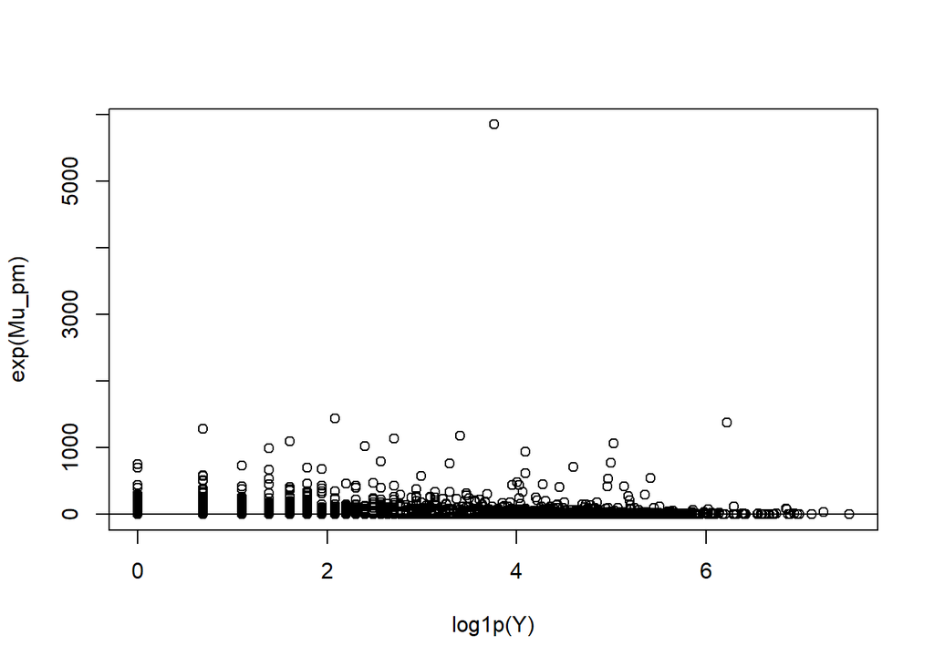